# Scores that share a sample

Catalog stamp 20260923. In the four AUC models below, cohort means the sample set.

Several scores can sit on one sample set. Different sample-set ids can still be the same study, including UK Biobank and Genes & Health. The average of all scores treats those evaluations as independent, so its interval is too narrow.

The four AUC models change the residual only. They do not put in the covariance between the European evaluations, or between the non-European evaluations, of scores that share a sample.

The covariance is built with `vcalc`, once for the European source and once for the non-European source. `rma.mv` fits the ancestry difference. `robust` gives a cluster-robust interval when the degrees of freedom are at least 4. This follows Pustejovsky & Tipton (2022) and the metafor manual page for dependent estimates. The paper is the one to confirm with Pirmin.

**With one sharing group, the interval depends on the assumed ρ. The reported intervals use ρ = 0.6.** Figure 9 draws ρ = 0, 0.3, 0.6, and 0.9. Five comparisons change whether the interval excludes zero from 0 to 0.9. Two of those still change between 0.3 and 0.9. 23 of the 24 comparisons with shared samples are one sharing group. 10 of 24 still exclude zero under the covariance model. The model is only for comparisons whose scores share people. The others keep the average of all scores. Shared samples alone widen the intervals 1.0–2.6×; the rest comes from variance between scores.

The linked-group bound, which puts ρ on every pair that shares any study, does not change whether any interval excludes zero. 12 of the 24 comparisons have only 2–3 scores and are flagged unstable for the between-score variance.

## Worked comparisons

The figures walk through one comparison, type 2 diabetes, South Asian participants, European-only training, and bring in the other comparisons where that example cannot show the step.

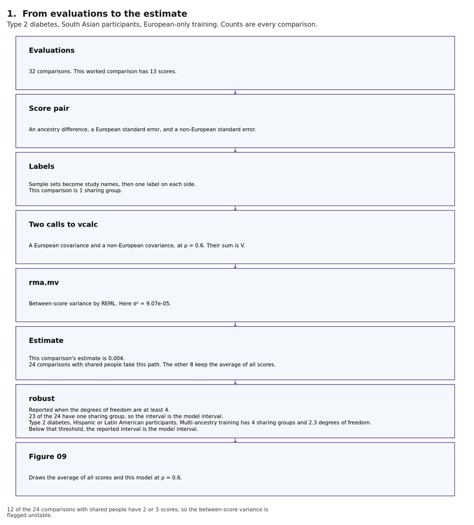

Each box is one step. The robust box is the one comparison with four sharing groups: 2.3 degrees of freedom, below the threshold of 4.

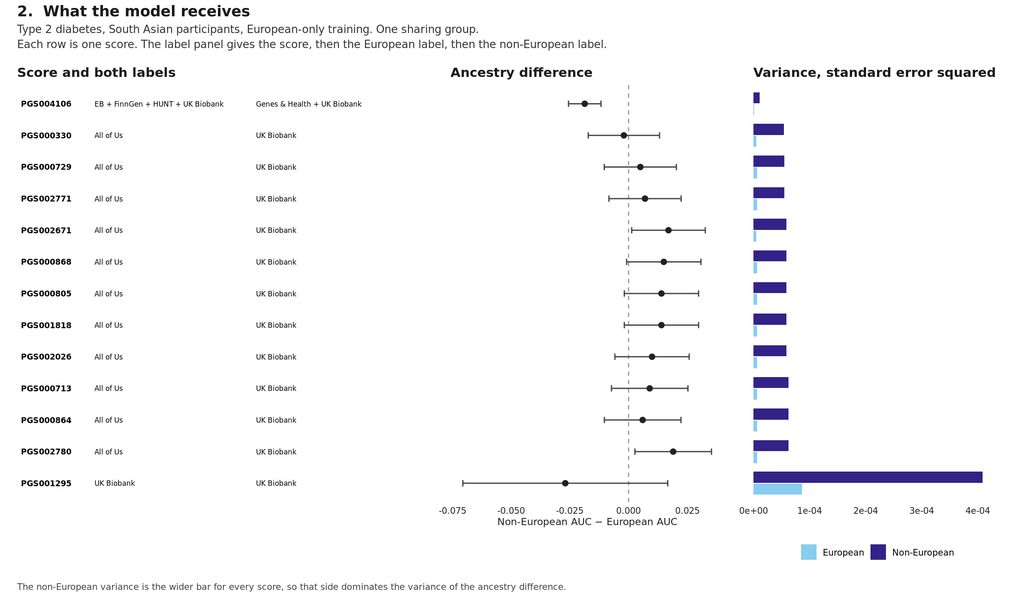

The ancestry difference, both labels, and the variance on each side. The non-European side dominates the variance.

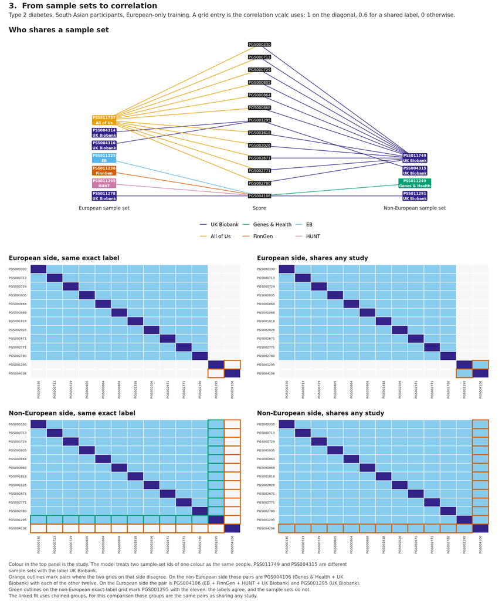

The model treats two sample-set ids with the same study name as the same people. PSS011749 and PSS004315 are different sample sets that share the label UK Biobank.

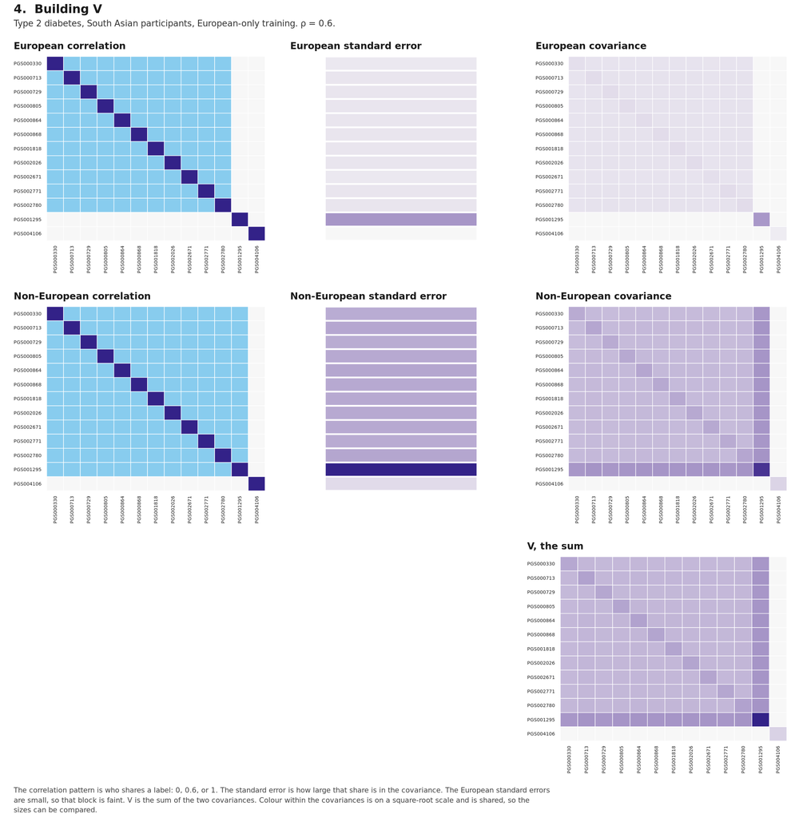

The correlation pattern is separate from the standard errors. V is the sum of the European and non-European covariances.

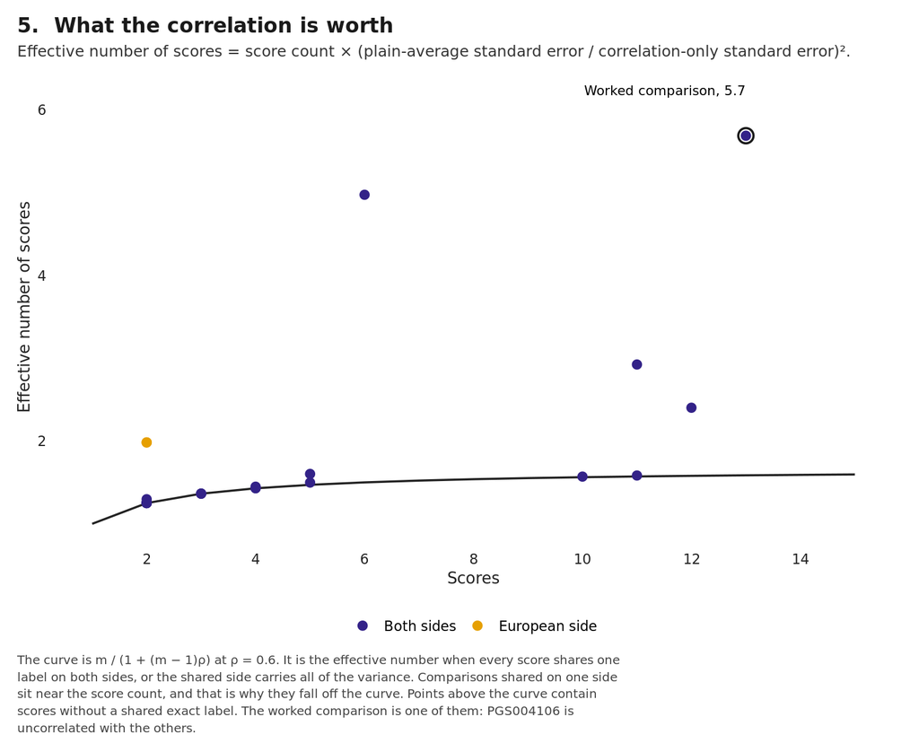

The curve holds when every score shares one label on both sides, or the shared side carries the variance. Points above the curve contain scores without a shared exact label.

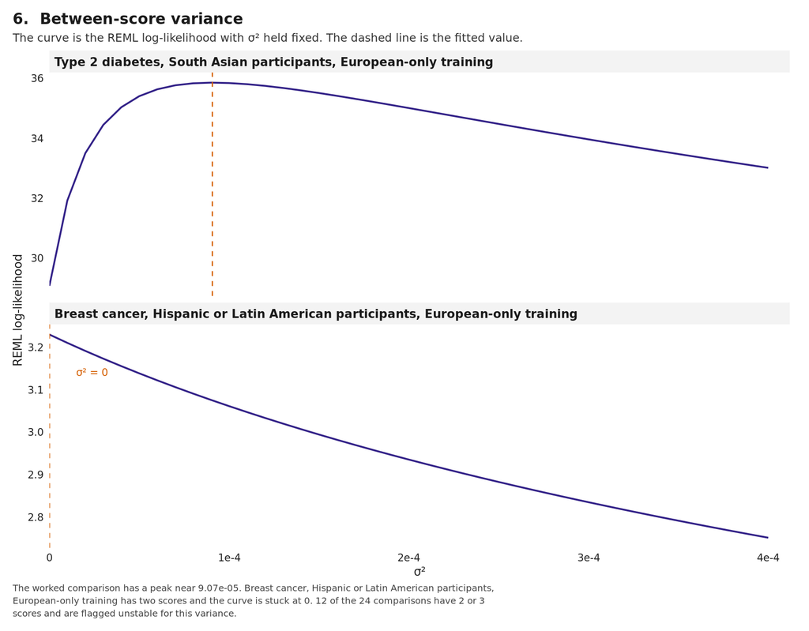

The worked comparison has a peak. Breast cancer, Hispanic or Latin American participants, European-only training is marked σ² = 0.

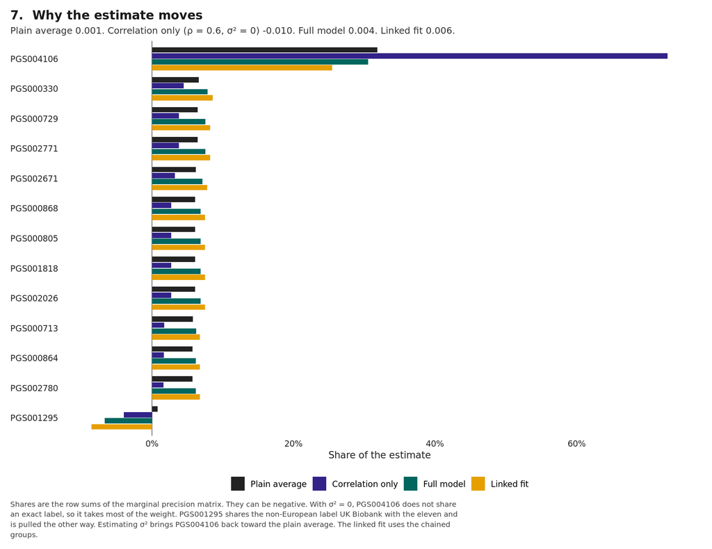

Plain average, correlation only, the full model, and the linked fit. These shares are why the estimate moves.

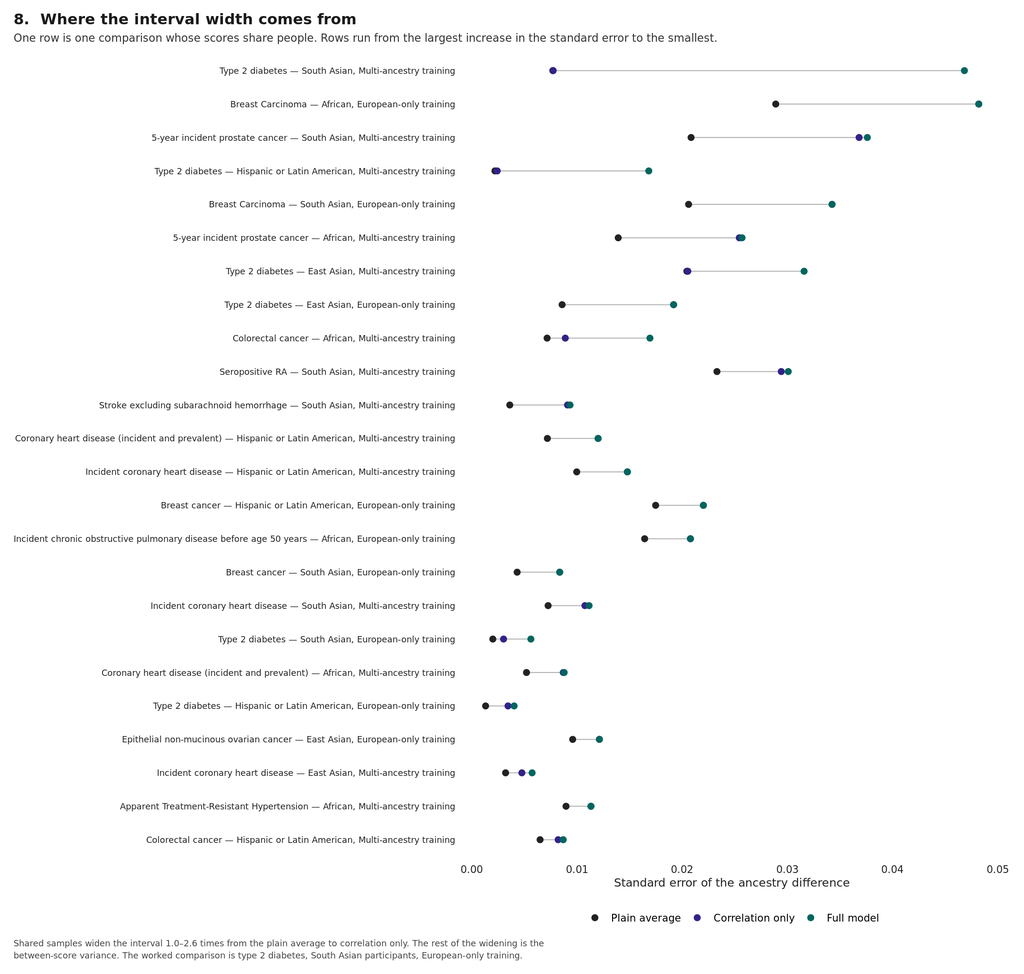

Shared samples widen the interval, and the between-score variance widens it further.

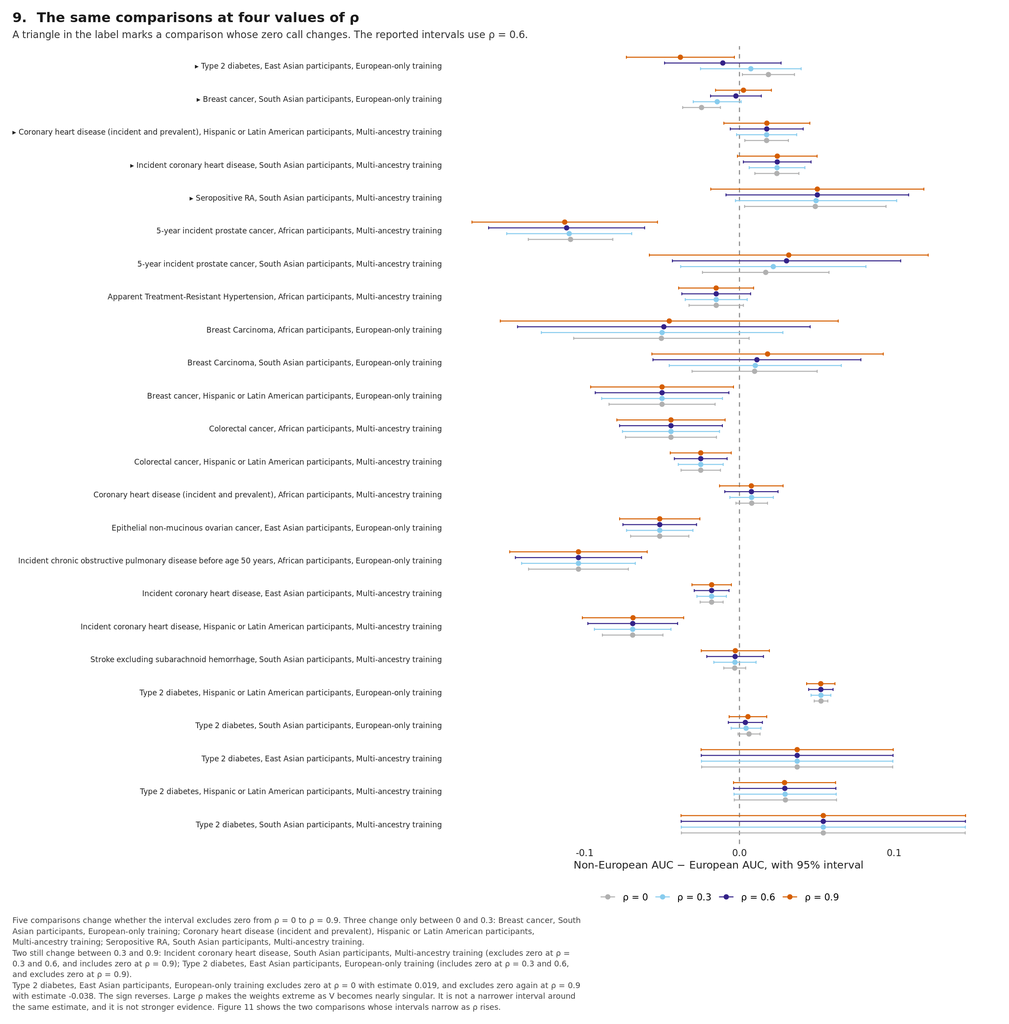

Five comparisons change their zero call from ρ = 0 to 0.9. Two of those still change between 0.3 and 0.9. For type 2 diabetes, East Asian participants, European-only training, the estimate changes sign and excludes zero on the other side at ρ = 0.9. That is extreme weights, not stronger evidence.

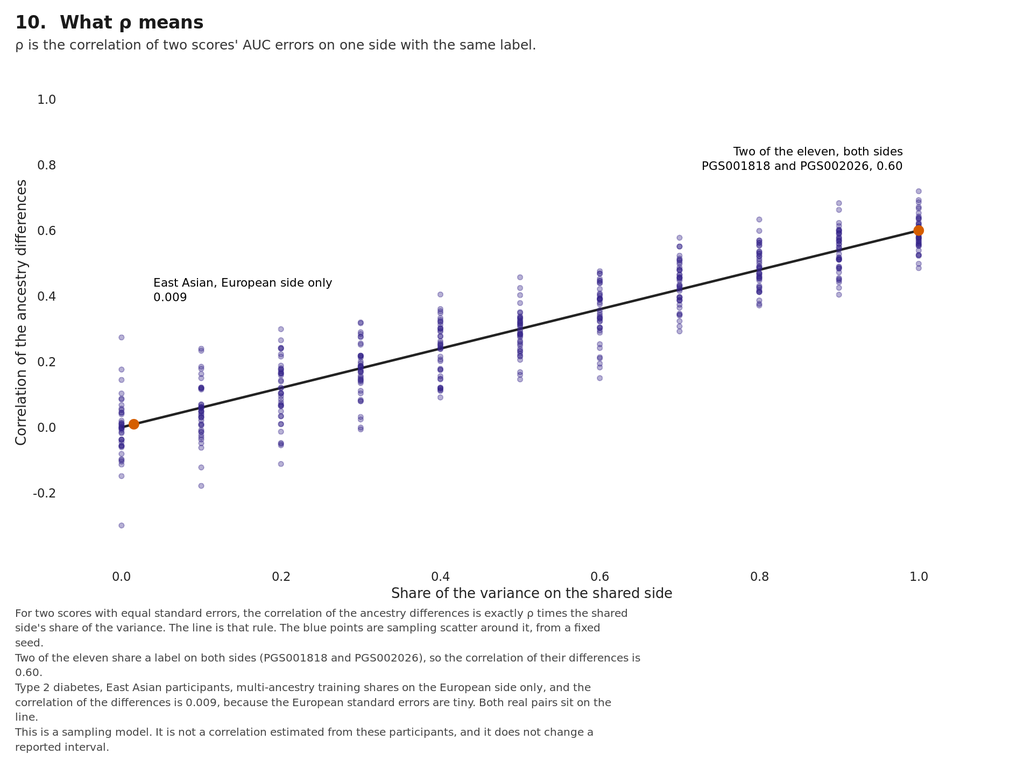

ρ is the correlation of two scores' AUC errors on one side with the same label. The line is the rule for the ancestry differences. This is a sampling model.

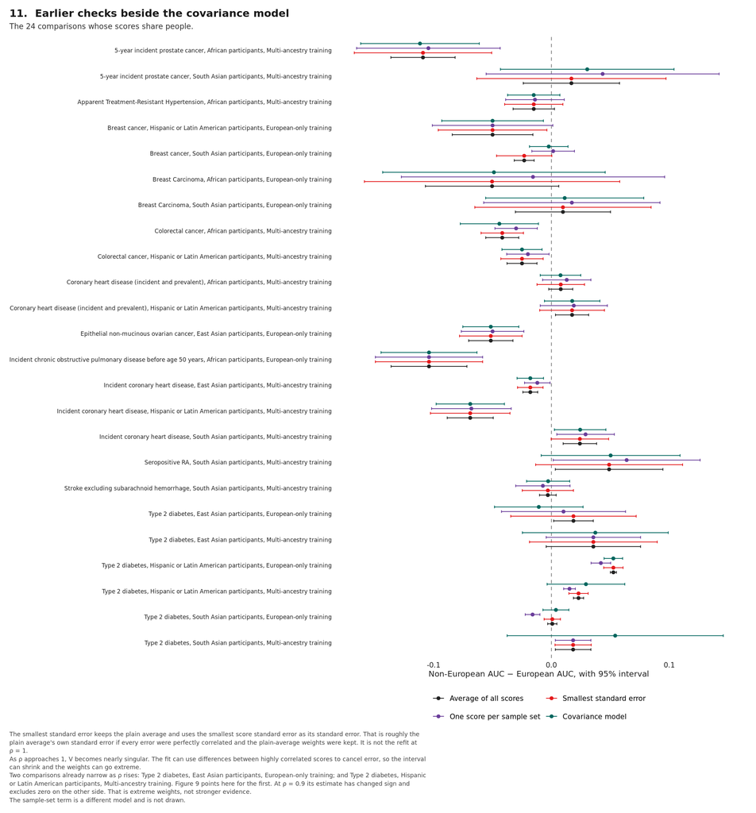

The average of all scores, the smallest standard error, one score per sample set, and the covariance model. The sample-set term is not drawn.

## Comparisons whose scores share people

| Trait | Training | Ancestry group | Scores | Shared side | Average of all scores | Covariance model | Excludes 0 | Shared samples only | Full model | Robust df |
| --- | --- | --- | --- | --- | --- | --- | --- | --- | --- | --- |
| 5-year incident prostate cancer | Multi-ancestry training | African | 5 | European and non-European | -0.1364 to -0.0818 | -0.1620 to -0.0613 | yes | 1.827 | 1.846 | — |
| 5-year incident prostate cancer | Multi-ancestry training | South Asian | 5 | European and non-European | -0.0239 to 0.0578 | -0.0433 to 0.1041 | no | 1.767 | 1.804 | — |
| Apparent Treatment-Resistant Hypertension | Multi-ancestry training | African | 2 | European and non-European | -0.0326 to 0.0025 | -0.0372 to 0.0072 | no | 1.265 | 1.265 | — |
| Breast Carcinoma | European-only training | African | 4 | European and non-European | -0.1071 to 0.0062 | -0.1433 to 0.0457 | no | 1.668 | 1.668 | — |
| Breast Carcinoma | European-only training | South Asian | 4 | European and non-European | -0.0306 to 0.0502 | -0.0559 to 0.0784 | no | 1.662 | 1.662 | — |
| Breast cancer | European-only training | Hispanic or Latin American | 2 | European and non-European | -0.0843 to -0.0157 | -0.0932 to -0.0068 | yes | 1.260 | 1.260 | — |
| Breast cancer | European-only training | South Asian | 11 | European and non-European | -0.0316 to -0.0147 | -0.0187 to 0.0141 | changes, now no | 1.940 | 1.940 | — |
| Colorectal cancer | Multi-ancestry training | African | 2 | European and non-European | -0.0558 to -0.0278 | -0.0774 to -0.0110 | yes | 1.242 | 2.367 | — |
| Colorectal cancer | Multi-ancestry training | Hispanic or Latin American | 2 | European and non-European | -0.0377 to -0.0123 | -0.0420 to -0.0080 | yes | 1.265 | 1.339 | — |
| Coronary heart disease (incident and prevalent) | Multi-ancestry training | African | 4 | European and non-European | -0.0023 to 0.0181 | -0.0095 to 0.0249 | no | 1.673 | 1.690 | — |
| Coronary heart disease (incident and prevalent) | Multi-ancestry training | Hispanic or Latin American | 4 | European and non-European | 0.0035 to 0.0316 | -0.0059 to 0.0412 | changes, now no | 1.672 | 1.672 | — |
| Epithelial non-mucinous ovarian cancer | European-only training | East Asian | 2 | European and non-European | -0.0703 to -0.0327 | -0.0753 to -0.0277 | yes | 1.265 | 1.265 | — |
| Incident chronic obstructive pulmonary disease before age 50 years | European-only training | African | 2 | European and non-European | -0.1362 to -0.0718 | -0.1447 to -0.0633 | yes | 1.265 | 1.265 | — |
| Incident coronary heart disease | Multi-ancestry training | East Asian | 3 | European and non-European | -0.0242 to -0.0117 | -0.0292 to -0.0067 | yes | 1.483 | 1.787 | — |
| Incident coronary heart disease | Multi-ancestry training | Hispanic or Latin American | 3 | European and non-European | -0.0885 to -0.0494 | -0.0979 to -0.0400 | yes | 1.483 | 1.483 | — |
| Incident coronary heart disease | Multi-ancestry training | South Asian | 3 | European and non-European | 0.0100 to 0.0384 | 0.0025 to 0.0462 | yes | 1.483 | 1.537 | — |
| Seropositive RA | Multi-ancestry training | South Asian | 2 | European and non-European | 0.0033 to 0.0947 | -0.0087 to 0.1093 | changes, now no | 1.262 | 1.291 | — |
| Stroke excluding subarachnoid hemorrhage | Multi-ancestry training | South Asian | 10 | European and non-European | -0.0101 to 0.0040 | -0.0211 to 0.0155 | no | 2.524 | 2.591 | — |
| Type 2 diabetes | European-only training | East Asian | 12 | European and non-European | 0.0019 to 0.0355 | -0.0484 to 0.0269 | changes, now no | 2.236 | 2.236 | — |
| Type 2 diabetes | European-only training | Hispanic or Latin American | 11 | European and non-European | 0.0501 to 0.0552 | 0.0447 to 0.0605 | yes | 2.636 | 3.084 | — |
| Type 2 diabetes | European-only training | South Asian | 13 | European and non-European | -0.0032 to 0.0046 | -0.0072 to 0.0148 | no | 1.512 | 2.816 | — |
| Type 2 diabetes | Multi-ancestry training | East Asian | 2 | European | -0.0045 to 0.0757 | -0.0247 to 0.0992 | no | 1.005 | 1.545 | — |
| Type 2 diabetes | Multi-ancestry training | Hispanic or Latin American | 6 | European and non-European | 0.0187 to 0.0273 | -0.0037 to 0.0623 | changes, now no | 1.099 | 7.667 | df 2.304, not reported |
| Type 2 diabetes | Multi-ancestry training | South Asian | 2 | European | 0.0033 to 0.0335 | -0.0377 to 0.1460 | changes, now no | 1.004 | 6.085 | — |

## Context: four AUC models on type 2 diabetes

These four models are the ones Nikolaus wrote down. They stay here as context. They are not the answer to the dependence question.

The input I need: which of the four models should account for several PGS evaluated on the same sample set, or whether you would rather drop rows than model the sharing.

- `lm(AUC ~ ancestry + PGS)`
- `lm(AUC ~ ancestry + PGS, weights = 1/SE^2)`
- `lmer(AUC ~ ancestry + PGS + (1|cohort), weights = 1/SE^2)`
- `lmer(AUC ~ ancestry + (1|PGS) + (1|cohort), weights = 1/SE^2)`

An evaluation is one AUC: one PGS, one sample set, one ancestry group, and one standard error. The sample-set term marks which evaluations share a sample set. It does not make the AUCs independent.

The four models are fit on type 2 diabetes. They can separate an ancestry group from a sample set only when a comparison uses more than one target sample set. Nine comparisons do. Seven are type 2 diabetes. The other two are breast cancer, European-only training: South Asian participants, and East Asian participants.

Eighteen comparisons have several PGS and one target sample set. Ancestry group and sample set are the same column there. The four models are not for that case. Five comparisons have one PGS.

## South Asian comparison

Europeans and South Asian participants, European-only training. Thirteen PGS, eleven of them on one UK Biobank sample set.

- Average of all scores (All PGS IVW): **0.0007** (-0.0032 to 0.0046).
- Check, one score per target sample set: **-0.0160** (-0.0223 to -0.0098).

## Two comparisons

South Asian participants, European-only training, are one of the nine. Thirteen scores, eleven of them on PSS011749. The average of all scores and one score per sample set are in the box above.

Hispanic or Latin American participants, European-only training, are one of the eighteen. Eleven scores, all on PSS011736, so ancestry group and sample set are the same column. The four models are not for that comparison.

## Evaluation table used here

80 evaluations. 19 PGS. 29 sample sets. 12 study names. Corrected logit values from `auc_ci_to_logit()`. AUC models use the delta-method SE (`SE_logit × AUC × (1 − AUC)`). Fits are separate for each training set. European is the reference ancestry group.

South Asian sample sets in the European-only training set:

- PSS011749 — UK Biobank (UKB), 11 evaluation(s)
- PSS004315 — UK Biobank (UKB), 1 evaluation(s)
- PSS011249 — Genes & Health (G&H), 1 evaluation(s)
- PSS011291 — UK Biobank (UKB), 1 evaluation(s)

CSV: `diabetes_evaluation_rows.csv`.

## European-only training

### East Asian

| Source | Sample set in the model | Estimate | 95% CI | Excludes 0 | Note |
| --- | --- | --- | --- | --- | --- |
| All PGS IVW | — | 0.0187 | 0.0019 to 0.0355 | yes |  |
| lm(AUC ~ ancestry + PGS) | — (not used) | 0.0240 | 0.0023 to 0.0458 | yes | A shared sample set is not marked. |
| lm(AUC ~ ancestry + PGS, weights = 1/SE^2) | — (not used) | 0.0119 | -0.1819 to 0.2056 | no | Point is 0.0119; All PGS IVW is 0.0187. This joint regression is not the average of all scores for that comparison. A shared sample set is not marked. |
| lmer(AUC ~ ancestry + PGS + (1\|cohort), weights = 1/SE^2) | sample-set id | 0.0029 | -0.1895 to 0.1953 | no | lmer convergence warning. |
| lmer(AUC ~ ancestry + (1\|PGS) + (1\|cohort), weights = 1/SE^2) | sample-set id | 0.0920 | -0.1572 to 0.3412 | no | 13 PGS as random intercepts. |

### Hispanic or Latin American

| Source | Sample set in the model | Estimate | 95% CI | Excludes 0 | Note |
| --- | --- | --- | --- | --- | --- |
| All PGS IVW | — | 0.0526 | 0.0501 to 0.0552 | yes |  |
| lm(AUC ~ ancestry + PGS) | — (not used) | 0.0509 | 0.0283 to 0.0735 | yes | A shared sample set is not marked. |
| lm(AUC ~ ancestry + PGS, weights = 1/SE^2) | — (not used) | 0.0453 | 0.0166 to 0.0740 | yes | Point is 0.0453; All PGS IVW is 0.0526. This joint regression is not the average of all scores for that comparison. A shared sample set is not marked. |
| lmer(AUC ~ ancestry + PGS + (1\|cohort), weights = 1/SE^2) | sample-set id | 0.0363 | -0.0099 to 0.0825 | no | lmer convergence warning. |
| lmer(AUC ~ ancestry + (1\|PGS) + (1\|cohort), weights = 1/SE^2) | sample-set id | 0.1251 | -0.0540 to 0.3042 | no | 13 PGS as random intercepts. |

### South Asian

| Source | Sample set in the model | Estimate | 95% CI | Excludes 0 | Note |
| --- | --- | --- | --- | --- | --- |
| All PGS IVW | — | 0.0007 | -0.0032 to 0.0046 | no |  |
| lm(AUC ~ ancestry + PGS) | — (not used) | 0.0012 | -0.0189 to 0.0214 | no | A shared sample set is not marked. |
| lm(AUC ~ ancestry + PGS, weights = 1/SE^2) | — (not used) | -0.0034 | -0.0482 to 0.0415 | no | Point is -0.0034; All PGS IVW is 0.0007. This joint regression is not the average of all scores for that comparison. A shared sample set is not marked. |
| lmer(AUC ~ ancestry + PGS + (1\|cohort), weights = 1/SE^2) | sample-set id | -0.0103 | -0.0614 to 0.0408 | no | lmer convergence warning. |
| lmer(AUC ~ ancestry + (1\|PGS) + (1\|cohort), weights = 1/SE^2) | sample-set id | -0.0149 | -0.1405 to 0.1107 | no | 13 PGS as random intercepts. |

## Multi-ancestry training

### African

| Source | Sample set in the model | Estimate | 95% CI | Excludes 0 | Note |
| --- | --- | --- | --- | --- | --- |
| All PGS IVW | — | -0.0585 | -0.0659 to -0.0511 | yes |  |
| lm(AUC ~ ancestry + PGS) | — (not used) | -0.0804 | -0.1591 to -0.0018 | yes | A shared sample set is not marked. |
| lm(AUC ~ ancestry + PGS, weights = 1/SE^2) | — (not used) | -0.1048 | -0.2285 to 0.0189 | no | Point is -0.1048; All PGS IVW is -0.0585. This joint regression is not the average of all scores for that comparison. A shared sample set is not marked. |
| lmer(AUC ~ ancestry + PGS + (1\|cohort), weights = 1/SE^2) | sample-set id | -0.1048 | -0.2285 to 0.0189 | no | 24 evaluations and 19 sample sets; 5 sample sets contain more than one PGS. The sample-set term is barely estimated. |
| lmer(AUC ~ ancestry + (1\|PGS) + (1\|cohort), weights = 1/SE^2) | sample-set id | -0.0543 | -0.1388 to 0.0302 | no | 24 evaluations and 19 sample sets; 5 sample sets contain more than one PGS. The sample-set term is barely estimated. 6 PGS as random intercepts. |

### East Asian

| Source | Sample set in the model | Estimate | 95% CI | Excludes 0 | Note |
| --- | --- | --- | --- | --- | --- |
| All PGS IVW | — | 0.0356 | -0.0045 to 0.0757 | no |  |
| lm(AUC ~ ancestry + PGS) | — (not used) | 0.0093 | -0.0923 to 0.1109 | no | A shared sample set is not marked. |
| lm(AUC ~ ancestry + PGS, weights = 1/SE^2) | — (not used) | -0.0074 | -0.8928 to 0.8781 | no | Point is -0.0074; All PGS IVW is 0.0356. This joint regression is not the average of all scores for that comparison. A shared sample set is not marked. |
| lmer(AUC ~ ancestry + PGS + (1\|cohort), weights = 1/SE^2) | sample-set id | -0.0074 | -0.8928 to 0.8781 | no | 24 evaluations and 19 sample sets; 5 sample sets contain more than one PGS. The sample-set term is barely estimated. |
| lmer(AUC ~ ancestry + (1\|PGS) + (1\|cohort), weights = 1/SE^2) | sample-set id | 0.0253 | -0.7853 to 0.8359 | no | 24 evaluations and 19 sample sets; 5 sample sets contain more than one PGS. The sample-set term is barely estimated. 6 PGS as random intercepts. |

### Hispanic or Latin American

| Source | Sample set in the model | Estimate | 95% CI | Excludes 0 | Note |
| --- | --- | --- | --- | --- | --- |
| All PGS IVW | — | 0.0230 | 0.0187 to 0.0273 | yes |  |
| lm(AUC ~ ancestry + PGS) | — (not used) | 0.0122 | -0.0492 to 0.0736 | no | A shared sample set is not marked. |
| lm(AUC ~ ancestry + PGS, weights = 1/SE^2) | — (not used) | -0.0051 | -0.0907 to 0.0805 | no | Point is -0.0051; All PGS IVW is 0.0230. This joint regression is not the average of all scores for that comparison. A shared sample set is not marked. |
| lmer(AUC ~ ancestry + PGS + (1\|cohort), weights = 1/SE^2) | sample-set id | -0.0051 | -0.0907 to 0.0805 | no | 24 evaluations and 19 sample sets; 5 sample sets contain more than one PGS. The sample-set term is barely estimated. |
| lmer(AUC ~ ancestry + (1\|PGS) + (1\|cohort), weights = 1/SE^2) | sample-set id | -0.0082 | -0.0808 to 0.0645 | no | 24 evaluations and 19 sample sets; 5 sample sets contain more than one PGS. The sample-set term is barely estimated. 6 PGS as random intercepts. |

### Middle Eastern or North African

| Source | Sample set in the model | Estimate | 95% CI | Excludes 0 | Note |
| --- | --- | --- | --- | --- | --- |
| All PGS IVW | — | 0.0059 | -0.0042 to 0.0160 | no |  |
| lm(AUC ~ ancestry + PGS) | — (not used) | 0.0683 | -0.0307 to 0.1672 | no | A shared sample set is not marked. |
| lm(AUC ~ ancestry + PGS, weights = 1/SE^2) | — (not used) | 0.0539 | -0.1686 to 0.2765 | no | Point is 0.0539; All PGS IVW is 0.0059. This joint regression is not the average of all scores for that comparison. A shared sample set is not marked. |
| lmer(AUC ~ ancestry + PGS + (1\|cohort), weights = 1/SE^2) | sample-set id | 0.0539 | -0.1686 to 0.2765 | no | 24 evaluations and 19 sample sets; 5 sample sets contain more than one PGS. The sample-set term is barely estimated. |
| lmer(AUC ~ ancestry + (1\|PGS) + (1\|cohort), weights = 1/SE^2) | sample-set id | 0.0461 | -0.1573 to 0.2495 | no | 24 evaluations and 19 sample sets; 5 sample sets contain more than one PGS. The sample-set term is barely estimated. 6 PGS as random intercepts. |

### South Asian

| Source | Sample set in the model | Estimate | 95% CI | Excludes 0 | Note |
| --- | --- | --- | --- | --- | --- |
| All PGS IVW | — | 0.0184 | 0.0033 to 0.0335 | yes |  |
| lm(AUC ~ ancestry + PGS) | — (not used) | 0.0333 | -0.0683 to 0.1349 | no | A shared sample set is not marked. |
| lm(AUC ~ ancestry + PGS, weights = 1/SE^2) | — (not used) | -0.0036 | -0.3334 to 0.3263 | no | Point is -0.0036; All PGS IVW is 0.0184. This joint regression is not the average of all scores for that comparison. A shared sample set is not marked. |
| lmer(AUC ~ ancestry + PGS + (1\|cohort), weights = 1/SE^2) | sample-set id | -0.0036 | -0.3334 to 0.3263 | no | 24 evaluations and 19 sample sets; 5 sample sets contain more than one PGS. The sample-set term is barely estimated. |
| lmer(AUC ~ ancestry + (1\|PGS) + (1\|cohort), weights = 1/SE^2) | sample-set id | -0.0091 | -0.3026 to 0.2844 | no | 24 evaluations and 19 sample sets; 5 sample sets contain more than one PGS. The sample-set term is barely estimated. 6 PGS as random intercepts. |

## Questions for Georg — one per model

### Unweighted regression: lm(AUC ~ ancestry + PGS)

Each PGS has its own baseline. Every evaluation has the same weight. A shared sample set is not marked.

Ancestry estimates:

| Training | Cohort | Ancestry | Estimate | 95% CI | Excludes 0 | Note |
| --- | --- | --- | --- | --- | --- | --- |
| European-only training | — (not used) | East Asian | 0.0240 | 0.0023 to 0.0458 | yes | A shared sample set is not marked. |
| European-only training | — (not used) | Hispanic or Latin American | 0.0509 | 0.0283 to 0.0735 | yes | A shared sample set is not marked. |
| European-only training | — (not used) | South Asian | 0.0012 | -0.0189 to 0.0214 | no | A shared sample set is not marked. |
| Multi-ancestry training | — (not used) | African | -0.0804 | -0.1591 to -0.0018 | yes | A shared sample set is not marked. |
| Multi-ancestry training | — (not used) | East Asian | 0.0093 | -0.0923 to 0.1109 | no | A shared sample set is not marked. |
| Multi-ancestry training | — (not used) | Hispanic or Latin American | 0.0122 | -0.0492 to 0.0736 | no | A shared sample set is not marked. |
| Multi-ancestry training | — (not used) | Middle Eastern or North African | 0.0683 | -0.0307 to 0.1672 | no | A shared sample set is not marked. |
| Multi-ancestry training | — (not used) | South Asian | 0.0333 | -0.0683 to 0.1349 | no | A shared sample set is not marked. |

Should the unweighted regression be the dependence model?

### Weighted regression: lm(AUC ~ ancestry + PGS, weights = 1/SE^2)

Ancestry estimates:

| Training | Cohort | Ancestry | Estimate | 95% CI | Excludes 0 | Note |
| --- | --- | --- | --- | --- | --- | --- |
| European-only training | — (not used) | East Asian | 0.0119 | -0.1819 to 0.2056 | no | Point is 0.0119; All PGS IVW is 0.0187. This joint regression is not the average of all scores for that comparison. A shared sample set is not marked. |
| European-only training | — (not used) | Hispanic or Latin American | 0.0453 | 0.0166 to 0.0740 | yes | Point is 0.0453; All PGS IVW is 0.0526. This joint regression is not the average of all scores for that comparison. A shared sample set is not marked. |
| European-only training | — (not used) | South Asian | -0.0034 | -0.0482 to 0.0415 | no | Point is -0.0034; All PGS IVW is 0.0007. This joint regression is not the average of all scores for that comparison. A shared sample set is not marked. |
| Multi-ancestry training | — (not used) | African | -0.1048 | -0.2285 to 0.0189 | no | Point is -0.1048; All PGS IVW is -0.0585. This joint regression is not the average of all scores for that comparison. A shared sample set is not marked. |
| Multi-ancestry training | — (not used) | East Asian | -0.0074 | -0.8928 to 0.8781 | no | Point is -0.0074; All PGS IVW is 0.0356. This joint regression is not the average of all scores for that comparison. A shared sample set is not marked. |
| Multi-ancestry training | — (not used) | Hispanic or Latin American | -0.0051 | -0.0907 to 0.0805 | no | Point is -0.0051; All PGS IVW is 0.0230. This joint regression is not the average of all scores for that comparison. A shared sample set is not marked. |
| Multi-ancestry training | — (not used) | Middle Eastern or North African | 0.0539 | -0.1686 to 0.2765 | no | Point is 0.0539; All PGS IVW is 0.0059. This joint regression is not the average of all scores for that comparison. A shared sample set is not marked. |
| Multi-ancestry training | — (not used) | South Asian | -0.0036 | -0.3334 to 0.3263 | no | Point is -0.0036; All PGS IVW is 0.0184. This joint regression is not the average of all scores for that comparison. A shared sample set is not marked. |

Should the weighted regression be the dependence model?

### Sample-set term, PGS fixed: lmer(AUC ~ ancestry + PGS + (1|cohort), weights = 1/SE^2)

In this model, cohort is the sample set. Evaluations from the same sample set share an offset, and the PGS stays a fixed intercept. Eleven South Asian PGS share PSS011749, and all of them are South Asian, so the sample-set offset and the ancestry coefficient compete for the same shift.

Ancestry estimates:

| Training | Cohort | Ancestry | Estimate | 95% CI | Excludes 0 | Note |
| --- | --- | --- | --- | --- | --- | --- |
| European-only training | sample-set id | East Asian | 0.0029 | -0.1895 to 0.1953 | no | lmer convergence warning. |
| European-only training | sample-set id | Hispanic or Latin American | 0.0363 | -0.0099 to 0.0825 | no | lmer convergence warning. |
| European-only training | sample-set id | South Asian | -0.0103 | -0.0614 to 0.0408 | no | lmer convergence warning. |
| Multi-ancestry training | sample-set id | African | -0.1048 | -0.2285 to 0.0189 | no | 24 evaluations and 19 sample sets; 5 sample sets contain more than one PGS. The sample-set term is barely estimated. |
| Multi-ancestry training | sample-set id | East Asian | -0.0074 | -0.8928 to 0.8781 | no | 24 evaluations and 19 sample sets; 5 sample sets contain more than one PGS. The sample-set term is barely estimated. |
| Multi-ancestry training | sample-set id | Hispanic or Latin American | -0.0051 | -0.0907 to 0.0805 | no | 24 evaluations and 19 sample sets; 5 sample sets contain more than one PGS. The sample-set term is barely estimated. |
| Multi-ancestry training | sample-set id | Middle Eastern or North African | 0.0539 | -0.1686 to 0.2765 | no | 24 evaluations and 19 sample sets; 5 sample sets contain more than one PGS. The sample-set term is barely estimated. |
| Multi-ancestry training | sample-set id | South Asian | -0.0036 | -0.3334 to 0.3263 | no | 24 evaluations and 19 sample sets; 5 sample sets contain more than one PGS. The sample-set term is barely estimated. |

Should the model with a sample-set term and a fixed PGS be the dependence model?

### PGS and sample set both random: lmer(AUC ~ ancestry + (1|PGS) + (1|cohort), weights = 1/SE^2)

Cohort is again the sample set. The PGS is a random intercept as well. European-only training has 13 PGS. Multi-ancestry training has 6.

Ancestry estimates:

| Training | Cohort | Ancestry | Estimate | 95% CI | Excludes 0 | Note |
| --- | --- | --- | --- | --- | --- | --- |
| European-only training | sample-set id | East Asian | 0.0920 | -0.1572 to 0.3412 | no | 13 PGS as random intercepts. |
| European-only training | sample-set id | Hispanic or Latin American | 0.1251 | -0.0540 to 0.3042 | no | 13 PGS as random intercepts. |
| European-only training | sample-set id | South Asian | -0.0149 | -0.1405 to 0.1107 | no | 13 PGS as random intercepts. |
| Multi-ancestry training | sample-set id | African | -0.0543 | -0.1388 to 0.0302 | no | 24 evaluations and 19 sample sets; 5 sample sets contain more than one PGS. The sample-set term is barely estimated. 6 PGS as random intercepts. |
| Multi-ancestry training | sample-set id | East Asian | 0.0253 | -0.7853 to 0.8359 | no | 24 evaluations and 19 sample sets; 5 sample sets contain more than one PGS. The sample-set term is barely estimated. 6 PGS as random intercepts. |
| Multi-ancestry training | sample-set id | Hispanic or Latin American | -0.0082 | -0.0808 to 0.0645 | no | 24 evaluations and 19 sample sets; 5 sample sets contain more than one PGS. The sample-set term is barely estimated. 6 PGS as random intercepts. |
| Multi-ancestry training | sample-set id | Middle Eastern or North African | 0.0461 | -0.1573 to 0.2495 | no | 24 evaluations and 19 sample sets; 5 sample sets contain more than one PGS. The sample-set term is barely estimated. 6 PGS as random intercepts. |
| Multi-ancestry training | sample-set id | South Asian | -0.0091 | -0.3026 to 0.2844 | no | 24 evaluations and 19 sample sets; 5 sample sets contain more than one PGS. The sample-set term is barely estimated. 6 PGS as random intercepts. |

Should the model with both the PGS and the sample set random be the dependence model?

## If dropping rows is preferred to modelling the sharing

- One PGS per sample set, the lowest PGS identifier: keeps 34 evaluations, drops 46 of 80.
- The largest sample set when one PGS is evaluated more than once in an ancestry group: keeps 74 evaluations, drops 6 of 80.

If you would rather drop rows than model the sharing, which rule do you prefer: one PGS per sample set, or the largest sample set when one PGS is evaluated more than once?

## Files

- `diabetes_evaluation_rows.csv`
- `diabetes_model_coefficients.csv` — the four models, plus the study-name fits and the metafor weight check
- `diabetes_reduced_rule_counts.csv`
- `diabetes_cohort_models.html` (this page)